# Lab3

Anna Matarazzo

3/13/2021

## Problems

### Problem 1

The problem for this week is to develop a little bit of content (tutorial material) that could be added to this lab. (6 points)

### The difference between partial and semi-partial correlation

The partial correlation coefficient is a measure that is used to describe the relationship between two random variables when BOTH of these variables are controlled (or partialled out) for the effects of a THIRD variable. In other words, the effect of the whole third variable is eliminated.

The semi-partial correlation describes the relationship between two variables when ONE of them is controlled for the effect of a THIRD variable. In other words, the effect of a fraction of a third variable is eliminated.

Let’s take a look at three variables: X, Y, Z. For the purposes of our example, the relationship of interest is between X and Y (so let’s call them variables of interest). To illustrate the difference between types of correlation, let’s consider the following scenarios:

### Scenario 1

**None of the variables of interest are correlated with Z.**

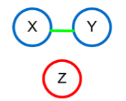

For this situation, all three types of correlation (correlation between all three variables, partial correlation and semi-partial correlation) have the identical value, since both X and Y have nothing to do with Z (Kim et al. (2012)).

Here is an example:

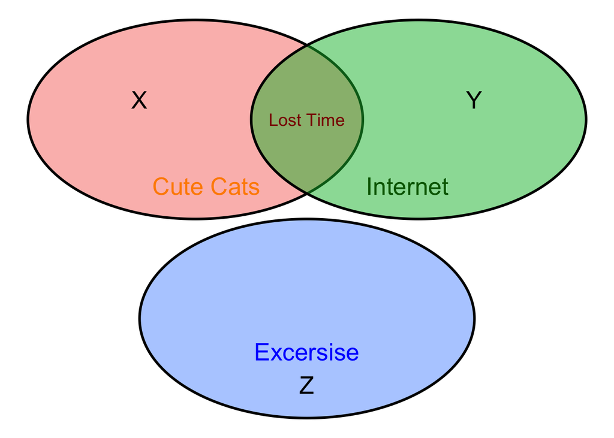

```r
# To create a Venn diagram with ggplot you have to manually draw and label circles

library(tidyverse)
library(ggforce) #adds geom_circle

#Data frame to specify circle and text position

data <- data.frame(x=c(0,1,-1),
                   y=c(-2,1,1),
                   tx=c(0,1.5,-1.5),
                   ty=c(-3, 1.3, 1.3),
                   cat = c("Z","Y","X"))

# Plot circles and add annotations

ggplot(data, aes(x0 = x, y0 = y, r =1.5, fill = cat)) +
  geom_circle(alpha=0.5, size=1, color="black", show.legend=FALSE) +
  geom_text(aes(x = tx, y = ty, label = cat), size=7) +
  annotate(geom="text", x=0, y=1, label="Lost Time", color="darkred", size=5) +
  annotate(geom="text", x=-0.9, y=0, label="Cute Cats",color="darkorange", size = 7) +
        annotate(geom="text", x=0.9, y=0, label="Internet",color="darkgreen", size = 7) +
        annotate(geom="text", x=0, y= -2.5, label="Excersise",color="blue", size = 7) +
        theme_void()
```

For this situation, “Lost Time” part of the Venn diagram will be both, partial and semi-partial correlation, as well as correlation of all three variables (see the table below):

```r
library("kableExtra")
text_tbl <- data.frame(
  Type_of_correlation = c("Correlation_xyz", "Partial_xy", "Semi-partial_xy"),
  Part_of_the_venn = c(
    "Lost Time",
    "Lost Time",
    "Lost Time"
  )
)

kbl(text_tbl) %>%
  kable_paper(full_width = F) %>%
  column_spec(1, bold = T, border_right = T) %>%
  column_spec(2, width = "10em", background = "lightyellow")
```

| Type_of_correlation | Part_of_the_venn |
| --- | --- |
| Correlation_xyz | Lost Time |
| Partial_xy | Lost Time |
| Semi-partial_xy | Lost Time |

### Scenario 2

**Both of the variables of interest are correlated with Z.**

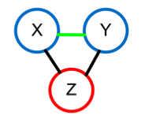

All three types of correlation are different in this situation.

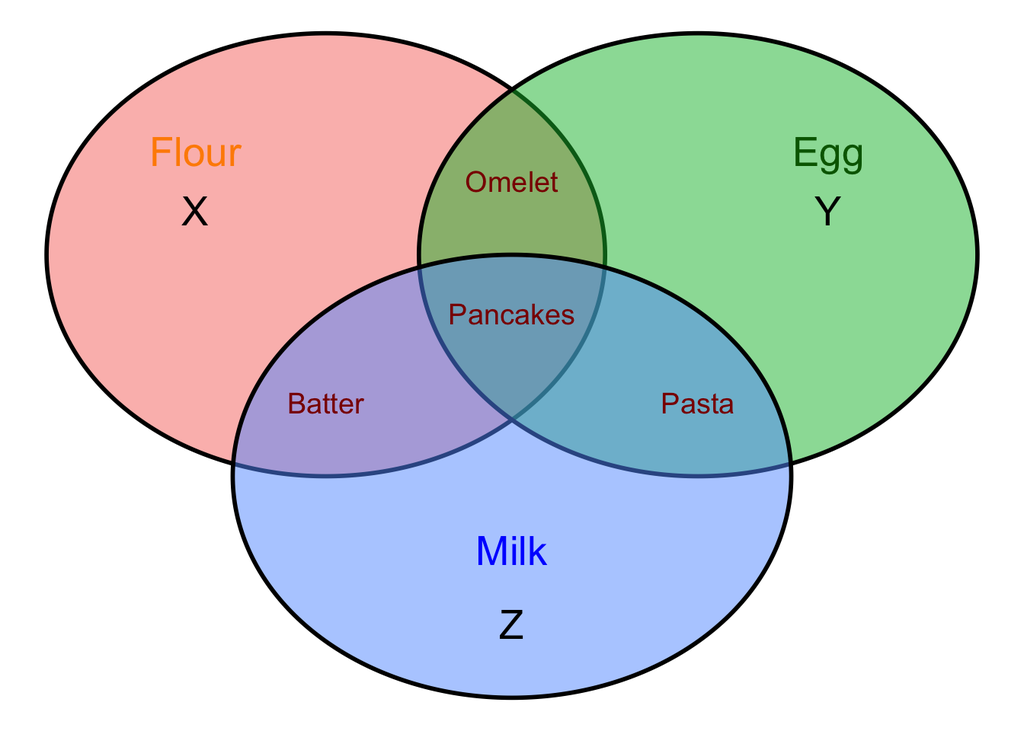

| Type_of_correlation | Part_of_the_venn |
| --- | --- |
| Correlation_xyz | Omelet + Pancakes + Batter + Pasta |
| Partial_xy | Omelet + Pancakes |
| Semi-partial_xy | Omelet |

### Scenario 3

**Only one variable of interest (for example, Y) is correlated with Z.**

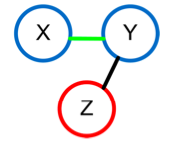

In case of this scenario, the partial correlation is exactly same as the semi-partial correlation, but is different from the correlation since Y is correlated with Z.

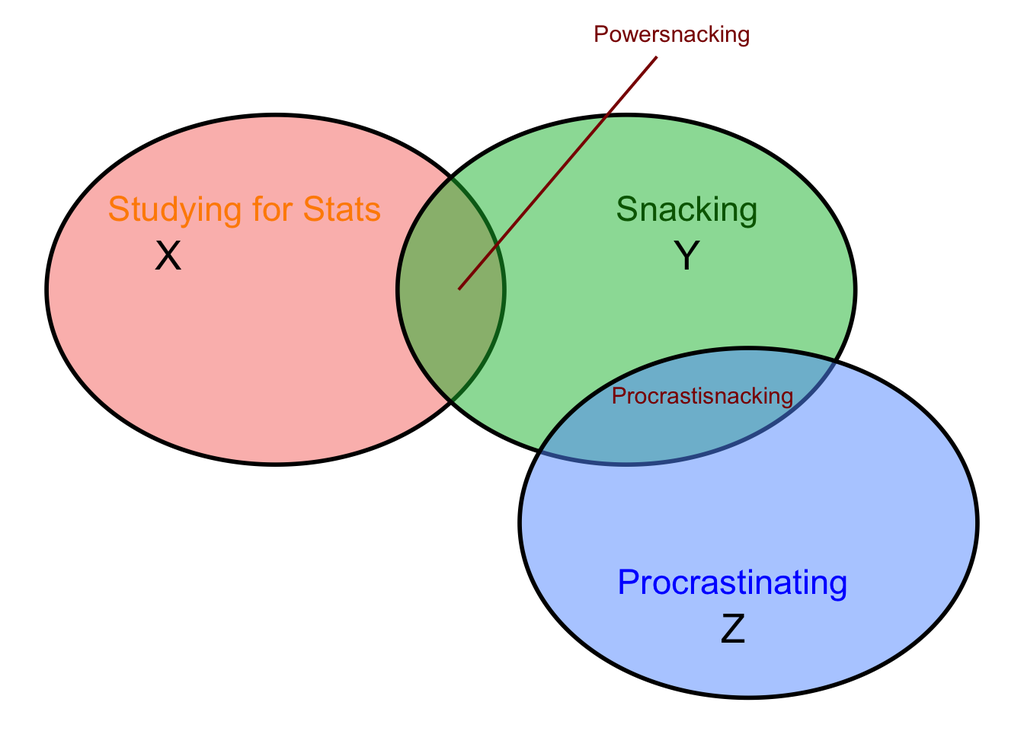

| Type_of_correlation | Part_of_the_venn |
| --- | --- |
| Correlation_xyz | Powersnacking + Procrastisnacking |
| Partial_xy | Powersnacking |
| Semi-partial_xy | Powersnacking |

The idea behind the partial and semi-partial correlations is to acquire a pure relationship between the two variables.

For example, even if X and Y are uncorrelated to each other, it’s possible to get nonzero correlation value due to Z, so by removing the effect of Z, we get true relationship between X and Y.

Similarly, the significant relationship between X and Y can be due to the hidden relationship between X and Z. For these reasons, the partial or the semi-partial correlations must be used to obtain the true relationship between X and Y.

## References

https://youtu.be/saFyipc7Wd8

Kim, Seongho, Imhoi Koo, Jaesik Jeong, Shiwen Wu, Xue Shi, and Xiang Zhang. 2012. “Compound Identification Using Partial and Semipartial Correlations for Gas Chromatography−mass Spectrometry Data.” *Analytical Chemistry* 84: 6477−6487. https://doi.org/10.1021.